# index

**How Does Accessibility to Commercial Districts Affect the Housing Values? A Case Study in Santa Monica, Los Angeles County**

Ta-Yun Yang

**Introduction**

The factors determining the housing value have been a popular research topic in both academic and business field. These factors can be generalized to three different aspects: Housing Characteristics, Demographic Factors and Geographical Variables. A housing property is more variable if it is newly built and located in decent neighborhood. In this project, the geographical section will be specified and the other elements will be considered as control variables for the housing price evaluation. After controlling demographic and property characteristics, I am particularly interested in the effect of accessibility to commercial services to the property values.

**Data and Methods**

Commercial districts will be defined as the census blocks which contain the 3 most commercial / industrial properties in the region. The data of the property type can be distinguished in Assessor Parcels Data from Los Angeles County. The parcels data includes more than two million rows for assessed property values and housing characteristics (number of bedrooms, number of bathrooms, building square footage, age) for every tax year. In this project, I plan to analyze the districts around Santa Monica with 3-5 tax year.

With the information of the coordinates in the parcels data, the demographic data from American Community Survey including median income, poverty rate and race can be merged via geojson file of the blocks. ACS dataset contains community information to the unit of Census Block. Finally, instead of calculating the direct distance of properties to the closest commercial district, using average traveling time from Uber Movement Data allows us to include influences from roads, urban planning and landscape. For every commercial district (Census Block), data of traveling time to all the remaining blocks will be collected and merged. The analysis should be done with consideration of the distance to closest commercial district or average distance to multiple districts.

**Hypothesis and Discussion**

Santa Monica region in Los Angeles County is an appropriate case for the project for several reasons. Firstly, public regional railway system in Greater Los Angeles Area is limited, and automobile remains the most common way for transportation. Thus, the average traveling time of Uber could be a close approximation. Secondly, the heavy industry with pollution which negatively affects the housing price is negligible. On the contrary, the existence of startup tech companies in the region might be positively correlated to the housing price. By concluding the above information, properties are expected to be more valuable if they are closer to commercial districts after demographic and housing patterns are controlled. The main purpose of this project is to test this hypothesis and discover the distribution of the effects.

```python
#@title Default title text
! git clone https://github.com/tayuny/Data_Viz_proj.git
```

```python
#@title Default title text
! pip install geopandas
import altair as alt
import pandas as pd
import numpy as np
import geopandas as geop
from shapely.geometry import Point
import re
import json
import warnings
from io import BytesIO
import requests
warnings.filterwarnings('ignore')

#@title Default title text
c_color_theme = ["#9cceff", "#2794ff", "#138bff", "#0063c4", "#0059b0", "#004f9c", "#004589"]
d_color_theme2 = ["#634c53", "#4b87ff", "#f2e522", "#cdd7d9", "#b0b0ff", "#b0d8ff", "#f27d22", "#ffcb64"]

def general_theme(*args, **kwargs):
    return {'width': 400, 'height': 500,
            'config': {"range": {"category": d_color_theme2, "diverging": c_color_theme},
                       'legend': {'titleFontSize': 12, 'labelFontSize': 12, "strokeColor":'gray',
                                  "fillColor":'#fefdee', "padding":12},
                       'axis': {'titleFontSize': 12, 'labelFontSize': 12},
                       "title":{"font": "Lato", "fontSize": 16, "color":"black"},
                       "header":{"titleFontSize":12}}}

alt.themes.register('general_theme', general_theme)
alt.themes.enable('general_theme')

#@title Default title text
full_data = pd.read_csv("Data_Viz_proj/data/full_data50.csv")
selected_columns = ['AIN', 'ZIPcode5', 'RollYear', 'CT','GeneralUseType', 'TotalValue', 'EffectiveYearBuilt', 'SQFTmain', 'Bedrooms', 'Bathrooms',
                    'unemployment', 'pop', 'gini', 'median_income','poverty_rate', 'pop75', 'Travel_Time701902', 'Travel_Time267800', 'TotalValue2017',
                    'TotalValue2016', 'TotalValue2015', 'TotalValue2014']
main_data = full_data[selected_columns]
main_data = main_data[main_data["median_income"] != "-"]
main_data["median_income"] = main_data["median_income"].astype(float)
plot_data = main_data.groupby("CT").median()

#@title Default title text
plot_data["med_inc_b"] = 0
over_all_mid_income = plot_data.groupby("CT").mean()["median_income"].median()
plot_data.loc[plot_data["median_income"] >= over_all_mid_income, "med_inc_b"] = 1
plot_data["CT"] = plot_data.index
plot_data["building_age"] = 2018 - plot_data["EffectiveYearBuilt"]

#@title Default title text
nearest10 = list(main_data.groupby("CT").mean()["Travel_Time701902"].sort_values(ascending=True)[:10].index.astype(str))
usage_CT_data = ((main_data[(main_data["GeneralUseType"] != "(missing)") & (main_data["GeneralUseType"] != "Dry Farm")]
                  ).groupby(["CT", "GeneralUseType"]).size() / \
                 main_data.groupby(["CT"]).size()
                 ).to_frame(name="use_ratio").reset_index()
usage_CT_data["CT"] = usage_CT_data["CT"].astype(str)
neighbor_dist = list(usage_CT_data[usage_CT_data["GeneralUseType"] == "Commercial"].sort_values(
              by="use_ratio", ascending=False)["CT"][:20])

building_usage = alt.Chart(usage_CT_data[usage_CT_data["CT"].isin(neighbor_dist)]).mark_bar().encode(
    x=alt.X('sum(use_ratio)', stack="normalize", axis=alt.Axis(title="Usage Ratio for specific buildings")),
    y=alt.Y("CT", axis=alt.Axis(title="Census Tract ID")),
    color=alt.Color("GeneralUseType", legend=alt.Legend(title=["Building", "Usage Type"]))
).properties(
    width = 500,
    height = 400,
    title = {"text" : "Percentage of Building Usage Type in Each Neighborhood",
             "subtitle" : ["20 Neighborhoods (with census tract number) which has highest ratio for commercial properties",
             "Region 701902 is selected to represent the Commercial District"]}
)

#@title Default title text
selected_columns = ['TotalValue', 'SQFTmain', 'Bedrooms', 'Bathrooms', 'unemployment', 'pop', 'gini',
                    'median_income', 'poverty_rate', 'pop75', 'Travel_Time701902', 'Travel_Time267800',
                    'CT', 'building_age']
geop_file = geop.read_file("Data_Viz_proj/data/full_sub_CL701902.geojson")
geop_file.loc[:, 'lon'] = geop_file.geometry.centroid.x
geop_file.loc[:, 'lat'] = geop_file.geometry.centroid.y
geop_sub = geop_file[geop_file["CT"] == 701902]

#@title Default title text
def plot_geo_from_file(center_CT, select_col, col_type, title_dict, legend_title, tooltip_col, center_color="black"):
    '''
    The function take the center census and select columns and
    provide geographical visualization for them
    Inputs:
        center_CT: commercial census tract
        select_cols: columns for visualization
        col_type: the type of the selected columns
    '''
    new_selected = "properties." + select_col + ":Q"
    save_dir = "Data_Viz_proj/data/full_sub_CL" + center_CT + ".geojson"

    with open(save_dir) as f:
        LA_shape_g = json.load(f)

    data_geojson = alt.InlineData(values=LA_shape_g, format=alt.DataFormat(property='features',type='json'))

    chart = alt.Chart(data_geojson).mark_geoshape(stroke="black").encode(
                        color=alt.Color(new_selected, type='quantitative', scale=alt.Scale(scheme="yellowgreenblue"), title=legend_title),
                        tooltip=tooltip_col
                        ).properties(
                            width=500,
                            height=400,
                      title=title_dict
    )

    label = alt.Chart(geop_file[geop_file["CT"] == 701902]).mark_text(color=center_color, text=["Commercial", "District"]).encode(
                                             latitude="lat",
                                             longitude="lon",
                                             )

    return chart + label
```

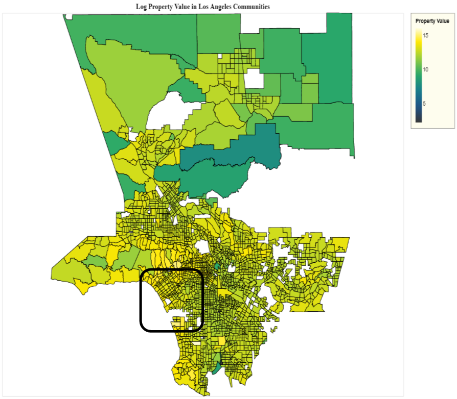

```python
#@title Default title text
#LA_shape = geop.read_file(r"D:\Project Data\Data_Viz project data\CL.geojson")
#LA_shape["TRACTCE"] = LA_shape["TRACTCE"].astype(str)

#parcels = pd.read_csv(r"D:\Project Data\Data_Viz project data\Assessor_Parcels_Data2018.csv")
#parcels = parcels[['ZIPcode5', 'AIN', 'RollYear', 'CENTER_LON', 'CENTER_LAT', 'GeneralUseType', 'TotalValue',
#                   'EffectiveYearBuilt', 'SQFTmain', 'Bedrooms', 'Bathrooms']]
#parcels["geometry"] = parcels.apply(lambda row: Point(row["CENTER_LON"], row["CENTER_LAT"]), axis=1)
#parcels = geop.GeoDataFrame(parcels, geometry="geometry")
#parcels.crs = LA_shape.crs

#full_geo = geop.tools.sjoin(parcels, LA_shape, how="inner", op="intersects")
#full_geo = full_geo[full_geo["TRACTCE"].notnull()]
#full_geo[full_geo["GeneralUseType"] == "Commercial"].groupby(
#         ["TRACTCE", 'GeneralUseType']).size().sort_values(ascending=False)[:3]
#full_geo.to_csv(r"D:\Project Data\Data_Viz project data\full_geo.csv")
#full_geo["CT"] = full_geo["TRACTCE"]
#plot_geo = full_geo.groupby("CT").median().reset_index()

#ex_condition = ["133000", "301000", "000303", "133000", "311000", "201200", "201401", "121600", "600100", "131100", "201700",
#               "430400", "201601", "201602", "430102", "402600","603400","103200", "201402","119201","601700","609900","501600",
#               "602900", "603200", "120400", "430101", "500300", "502902", "502301", "602700", "119202","430101", "433102",
#               "603802", "602700", "122000", "404600", "430600", "601501", "401500", "980004", "599100", "501200", "431100",
#                "599000","504001", "502302", "602600", "601502", "407102", "433700", "504102", "504101","502601", "502500",
#               "603900", "601100", "405500", "430200", "503602", "501900", "500600", "502901", "400800", "402200", "404501",
#                "406000", "405302", "407101", "430200", "500500", "603801", "406602", "403000", "501700", "503802", "500800",
#               "431200", "433200","400900","401800", "404000", "403000", "405301", "405600", "407400", "406300", "405600",
#               "602200", "403600", "405800", "407900", "408800", "407200", "406500", "405800", "432300", "432700","500100",
#               "403702", "406601", "406800", "503902", "503601", "501300", "503703", "503902", "503601", "501501", "503105",
#               "504002", "503402", "503401"]

#plot_geo = pd.read_csv(r"D:\Project Data\Data_Viz project data\plot_geo.csv")
#LA_shape = geop.read_file(r"D:\Project Data\Data_Viz project data\CL.geojson")
#LA_shape["TRACTCE"] = LA_shape["TRACTCE"].astype(str)
#plot_geo["TRACTCE"] = plot_geo["CT"].astype(str)
#plot_geo = LA_shape.merge(plot_geo, on="TRACTCE")
#plot_geo = plot_geo[plot_geo["TotalValue"] != 0]

#plot_geo = plot_geo[~plot_geo["TRACTCE"].isin(ex_condition)]
#plot_geo["lvalue"] = np.log(plot_geo["TotalValue"])
#plot_geo.to_file(r"D:\Project Data\Data_Viz project data\plot_geo.geojson", driver='GeoJSON')

#save_dir = r"D:\Project Data\Data_Viz project data\plot_geo.geojson"
#with open(save_dir) as f:
#    LA_shape_g = json.load(f)

#data_geojson = alt.InlineData(values=LA_shape_g, format=alt.DataFormat(property='features',type='json'))

#chart = alt.Chart(data_geojson).mark_geoshape(stroke="black").encode(
#                        color=alt.Color("properties.lvalue:Q", type='quantitative', scale=alt.Scale(scheme="darkmulti"), title="Property Value"),
#                        tooltip=["properties.lvalue:Q","properties.CT:N", "properties.SQFTmain:Q",
#                                 "properties.EffectiveYearBuilt:Q", "properties.CENTER_LAT:Q", "properties.CENTER_LON:Q"]
#                        ).properties(
#                            width=1000,
#                            height=800,
#                      title={"title":"Property Value in Los Angeles Communities",
#                             "subtitle":"presented in log value"}
#    )
#chart

from PIL import Image
img = Image.open('Data_Viz_proj/data/Copy of LA_map.png')
img
```

The distribution of property values in Los Angeles is diversed and might be attributed to factors in multiple aspects. The following research will focus on Santa Monica which is mark in the above map.

```python
#@title Default title text
tooltip_col = ["properties.CT:N", "properties.SQFTmain:Q", "properties.EffectiveYearBuilt:Q"]
title_dict = {"text": ["The Location of Commercial District in Santa Monica and the Corresponding Traveling Time to it"],
              "subtitle": ["Commercial District of Santa Monica is Located along the coast, traveling time is shorter along the coast"]}
travel_chart = plot_geo_from_file("701902", "Travel_Time701902", "Q", title_dict , ["Traveling Time", "To Commercial", "District"], tooltip_col)
```

```python
#@title Default title text
building_usage | travel_chart
```

[interactive chart not shown]

- Data Source: Los Angeles County Parcels Data, Uber Movement Data

Since the main purpose of the project is to evaluate the relation between the traveling time to commercial district and the property values. First of all, a clear definition of commercial district is necessary for this purpose. The ratio of the building usage type in all regions are presented as the following. We can observe that census tract 701902 (neighborhood) has both high number and proportion of commercial properties. Thus, I define census tract 701902 as commercial district in the following research. Given the fact that region 702300 which contains the most commercial properties are close to tract 701902 (less than 5 min), the commercial districts is concentrated in Santa Monica. Moreover, since the main commercial district of Santa Monica is located along the coast (marked in the map), the traveling time to it is expected to be longer for the inland neighborhoods.

```python
#@title Default title text
com_per = pd.DataFrame(np.percentile(main_data[main_data["GeneralUseType"] == "Commercial"]["TotalValue"], np.arange(1,99,1)), columns=["Property_Value"])
com_per["Use_Type"] = "Commercial"
com_per["percentile"] = com_per.index
ind_per = pd.DataFrame(np.percentile(main_data[main_data["GeneralUseType"] == "Industrial"]["TotalValue"], np.arange(1,99,1)), columns=["Property_Value"])
ind_per["Use_Type"] = "Industrial"
ind_per["percentile"] = com_per.index
res_per = pd.DataFrame(np.percentile(main_data[main_data["GeneralUseType"] == "Residential"]["TotalValue"], np.arange(1,99,1)), columns=["Property_Value"])
res_per["Use_Type"] = "Residential"
res_per["percentile"] = res_per.index
total_per = pd.concat([res_per, com_per], join="inner")
total_per = pd.concat([total_per, ind_per], join="inner")

#@title Default title text
accu = alt.Chart(total_per).mark_area(opacity=0.3).encode(
    x=alt.X("percentile:O", title="Percentile of Each Property Type"),
    y=alt.Y("Property_Value:Q", title="Property Value of the Specific Percentile (Black Line: median property value)"),
    color=alt.Color("Use_Type:N", title="Property Type"),
    opacity=alt.value(0.8)
).properties(
    width = 600,
    height = 400,
    title={"text": "Property Value of Each Percentile with Different Building Type",
           "subtitle": ["The property value increase exponentially at the higher percentile, the distribution is unbalance",
                        "Buildings with higher profitability (Commercial and Industrial) have higher value and skewedness"]}
)

global_median = alt.Chart(total_per).mark_rule(color='black').encode(
    y = alt.Y('median(Property_Value):Q'),
)

(accu + global_median)
```

[interactive chart not shown]

- Data Source: Los Angeles County Parcels Data

The research focus on residential, commercial and industrial properties which are more relevant to the daily life of the public. We can discover that the distribution is skewed that the high-valued properties contain extremely high value comparing to the rest. The skewedness is more severe in commercial and industrial properties, which is reasonable since these properties are more valuable because of their profitability.

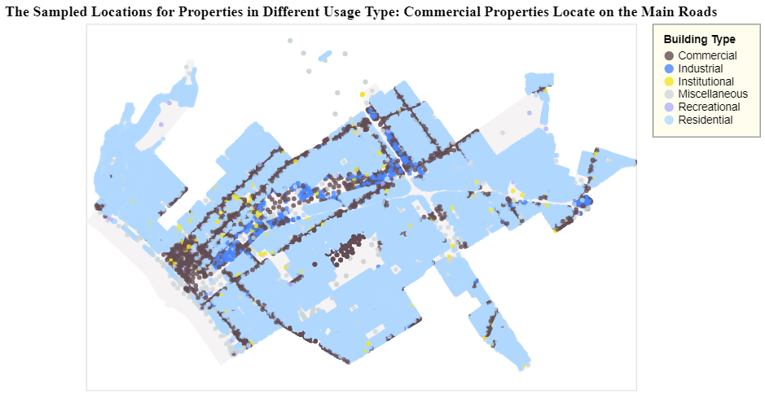

```python
#@title Default title text
#alt.data_transformers.disable_max_rows()
MT_data = pd.DataFrame(columns=full_data.columns)
for c in pd.unique(full_data["CT"]):
    sub_data = full_data[full_data.CT == c].reset_index(drop=True)
    sub_size = sub_data.shape[0]
    sel_idx = np.random.permutation(sub_size)[:int((sub_size * 0.05) // 1)]
    MT_data = pd.concat([MT_data, sub_data.iloc[sel_idx]])
#MT_data = full_data

allCT = pd.unique(full_data["CT"])
geopf = geop.read_file("Data_Viz_proj/data/full_sub_CL701902.geojson")
sub_full = geopf[geopf["CT"].isin(allCT)]
sub_full.to_file("Data_Viz_proj/data/full_sub_CL701902_part.geojson", driver='GeoJSON')

#@title Default title text
save_dir = "Data_Viz_proj/data/full_sub_CL701902_part.geojson"
with open(save_dir) as f:
    LA_shape_g = json.load(f)

data_geojson = alt.InlineData(values=LA_shape_g, format=alt.DataFormat(property='features',type='json'))

background = alt.Chart(data_geojson).mark_geoshape(color="#f6f3f4").encode().properties(
                            width=600,
                            height=400
                        )

chart = alt.Chart(MT_data[MT_data.GeneralUseType != "(missing)"]
    ).mark_circle(size=25).encode(
        longitude='CENTER_LON:Q',
        latitude='CENTER_LAT:Q',
        color=alt.Color("GeneralUseType", title="Building Type"),
        opacity = alt.value(0.8)
    ).properties(
        width=600,
        height=400,
        title={"text": "The Sampled Locations for Properties in Different Usage Type",
               "subtitle": ["residential properties locate in the specific blocks and",
                            "commercial properties tend to locate along the main roads and commercial district"]}
    )
#background + chart

#@title Default title text
# Using the full_data in the plotting of local device
from PIL import Image
img = Image.open('Data_Viz_proj/data/building_points.png')
img
```

- Data Source: Los Angeles County Parcels Data

The geographical distribution of the commercial properties is also unbalanced. Most of the commercial properties located in specific commercial districts or the main roads. This pattern might eliminate the effect of the distance to main commercial districts since the main roads are not located in the same neighborhoods. In comparison, the residential properties are placed in blocks in specific areas.

```python
#@title Default title text
chart_SQFTmain = alt.Chart(plot_data).mark_rect().encode(
    x=alt.X('unemployment:Q', axis=alt.Axis(title="Unemployment Rate in the Neighborhood"), bin=alt.Bin(maxbins=20) ),
    y=alt.Y('median_income:Q', axis=alt.Axis(title="Median Income in the Neighborhood"), bin=alt.Bin(maxbins=20)),
    color=alt.Color('TotalValue:Q', title="Property Value")
)

circ = chart_SQFTmain.mark_point().encode(
    alt.ColorValue('grey'),
    alt.Size('pop',
        legend=alt.Legend(title=['Population in ', "the Region"])
    ),
    tooltip=alt.Tooltip('CT:N', title='Neighborhood')
)

(chart_SQFTmain + circ).properties(
    width = 500,
    height = 400,
    title={"text": "Relation Between Median Income, Unemployment Rate, Population and Property Value",
           "subtitle": ["In general, neighborhood with higher median income tend to have higher median property value",
                        "the main commercial district (blue cell at the right bottom) is surprisingly characterized with",
                        "high property values, low median income and high unemployment rate"]}
)
```

[interactive chart not shown]

We then take a look into the demographic patterns related to the neighborhoods in Santa Monica. It is a mild trend that in general, neighborhoods with higher median income tend to have higher median property value although this effect is more significant only when the median income is high enough to certain level. On the other hand, there is not clear tendency for the unemployment rate with the property values. Surprisingly, we can clearly see an outlier in this case that the commercial district has relatively low median income and high unemployment rate which are not corresponding to its high median property values.

```python
#@title Default title text
tooltip_col = ["properties.CT:N", "properties.SQFTmain:Q", "properties.EffectiveYearBuilt:T"]
title_dict = {"text": ["The Distribution of Median Property Value Among Neighborhoods in Santa Monica"],
              "subtitle": ["the median property value in the commercial district is high because of its profitability",
                           ", where most of the industrial and commercial properties located"]}
geo1 = plot_geo_from_file("701902", "TotalValue", "Q", title_dict , ["Median Property", "Value in the", "Region"], tooltip_col, "white")

#@title Default title text
tooltip_col = ["properties.CT:N", "properties.poverty_rate:N", "properties.pop:Q"]
title_dict = {"text": ["The Distribution of Median Income Among Neighborhoods in Santa Monica"],
              "subtitle": ["the median income of the neighborhoods are low in the center of the city (commercial district)",
                           "and it is relatively high in the sub-urban area"]}
geo2 = plot_geo_from_file("701902", "median_income", "Q", title_dict , ["Median Income", "in the", "Region"], tooltip_col)

(geo1 | geo2).resolve_scale(color='independent')
```

[interactive chart not shown]

- Data Source: Los Angeles County Parcels Data, Uber Movement Data, American Community Survey

The above maps demonstrate that the neighborhoods in the sub-urban area tend to have slightly higher property values and median income comparing to the city center. Although the commercial district contains extremely high property values, its local residents are not directly benefited since the high values are attributed to the commercial properties, where the customers and business owner might not live in the region. We are then interested in the factors that drive the property values in the outskirts besides its profitability.

```python
#@title Default title text
sqft_perc = np.percentile(main_data["SQFTmain"], np.arange(0,100,1))
main_data["SQFT_group"] = 0
for i, q in enumerate(sqft_perc[:-1]):
  main_data.loc[(main_data["SQFTmain"] > sqft_perc[i + 1]) & (main_data["GeneralUseType"] == "Residential"), "SQFT_group"] = i + 1
  rep_main = main_data.groupby("SQFT_group").median().reset_index()

#@title Default title text
rel1 = alt.Chart(rep_main[rep_main["SQFT_group"] <= 95]).mark_circle().encode(x=alt.X('SQFTmain:Q', axis=alt.Axis(title="Square Footage of a Building")),
                                         y=alt.Y('TotalValue:Q', axis=alt.Axis(title="Approximated Property Value (Black line: median)")),
                                         color=alt.Color("Travel_Time701902:Q", title= ["Traveling Time", "to Commercial","District"]),
                                         size=alt.Size("TotalValue", title="Property Value")
).properties(
    width = 500,
    height = 400,
    title = {"text": ["Relation between Housing Value, Housing Square Footage, and Traveling Time to Commercial Districts",
             "for Residential Properties"],
             "subtitle": ["Linear relation between building square footage and the property value is clear until a certain level, ",
                          "Buildings with higher square footage and higher value tend to have higher traveling time to the city center"]}
)

global_median1 = alt.Chart(rep_main).mark_rule(color='black').encode(
    y=alt.Y('median(TotalValue):Q'),
)

#@title Default title text
sqft_perc = np.percentile(main_data["SQFTmain"], np.arange(0,100,1))
main_data["SQFT_group"] = 0
for i, q in enumerate(sqft_perc[:-1]):
  main_data.loc[(main_data["SQFTmain"] > sqft_perc[i + 1]) & (main_data["GeneralUseType"] == "Commercial"), "SQFT_group"] = i + 1
  rep_main = main_data.groupby("SQFT_group").median().reset_index()

#@title Default title text
rel2 = alt.Chart(rep_main[rep_main["SQFT_group"] <= 95]).mark_circle().encode(x=alt.X('SQFTmain:Q', axis=alt.Axis(title="Square Footage of a Building")),
                                         y=alt.Y('TotalValue:Q', axis=alt.Axis(title="Total Value of a Building (Black line: median)")),
                                         color=alt.Color("Travel_Time701902:Q", title= ["Traveling Time", "to Commercial","District"]),
                                         size=alt.Size("TotalValue", title="Property Value")
).properties(
    width = 500,
    height = 400,
    title = {"text": ["Relation between Housing Value, Housing Square Footage, and Traveling Time to Residential Districts",
             "for Commercial Properties"],
             "subtitle": ["The linear relation between these characteristics for the residential properties is not observed in",
                          "the case of commercial properties"]}
)

global_median2 = alt.Chart(rep_main).mark_rule(color='black').encode(
    y=alt.Y('median(TotalValue):Q'),
)

(rel1 + global_median1 | rel2 + global_median2)
```

[interactive chart not shown]

Note: House Value labelled in the graph is approximated by the median house value of given neighborhood

- Source: Los Angeles County Parcels Data, Uber Movement Data, American Community Survey

There exist possibilities that the value of a residential property is driven by its own housing characteristics beside all factors in the community. A clear linear pattern between square footage of a residential building and its value can be observed since higher square footage of a building could result in higher living qualities. Furthermore, they are both positively correlated with the traveling time to the main commercial district. This provides us an explanation that the high value of the properties in the sub-urban regions might be attributed to the value of higher living qualities. In contrast, we do not observe the similar clear pattern in commercial properties although properties with extremely large square footage are still more valuable. The value of the commercial properties is more likely to be related to its profitability and locations.

```python
#@title Default title text
def create_yearly_table(grouped_data, selected_columns, year_list,
                        group_col="CT", group_thres=np.arange(0,1,0.2)):
    '''
    The function take the summarized table with the selected columns and year list
    and provide information of the time trend for different sub-group specified in
    group_col parameter
    Inputs:
        grouped_data: summarized table for census tracts
        selected_columns: columns to be kept in the final table
        year_list: The tax year for House Value included
        group_col: columns for creating sub-groups
        group_thres: percentile taken to group the group_col
    Return: summarized table grouped by group_col and year
    '''
    final_df = grouped_data[selected_columns]
    final_df["year"] = 2018
    if group_col != "CT":
        for i, thres in enumerate(group_thres):
            final_df.loc[final_df[group_col] >= final_df[group_col].quantile(
                         thres), group_col + "_b"] = i * 20

    for year in year_list:
        temp = grouped_data
        valcol = "TotalValue" + str(year)
        temp["TotalValue"] = temp[valcol]
        temp = temp[selected_columns]
        temp["year"] = year
        if group_col != "CT":
            for i, thres in enumerate(group_thres):
                temp.loc[temp[group_col] >= temp[group_col].quantile(
                         thres), group_col + "_b"] = i * 20

        final_df = pd.concat([final_df, temp], join="inner")

    return final_df

#@title Default title text
plot_data["building_age"] = 2018 - plot_data["EffectiveYearBuilt"]
selected_columns = ['AIN', 'ZIPcode5', 'RollYear', 'TotalValue', 'EffectiveYearBuilt',
                     'SQFTmain', 'Bedrooms', 'Bathrooms', 'unemployment', 'pop', 'gini',
                     'median_income', 'poverty_rate', 'pop75', 'Travel_Time701902',
                     'Travel_Time267800', 'building_age']

final_plot_data = create_yearly_table(plot_data, selected_columns, [2014, 2015, 2016,2017])

#@title Default title text
step = 60
overlap = 1

alt.Chart(final_plot_data, height=step, width=600).transform_joinaggregate(
         median_value="median(TotalValue)", groupby=["year"]
    ).transform_bin(
         ['bin_max', 'bin_min'], 'TotalValue'
    ).transform_aggregate(
        value='count()', groupby=["year", "median_value", "bin_min", "bin_max"]
    ).transform_impute(
        impute="value", groupby=["year", "median_value"], key="bin_min", value=0
    ).mark_area(
        interpolate='monotone',
        fillOpacity=0.8,
        stroke='lightgray',
        strokeWidth=0.5
    ).encode(
        alt.X('bin_min:Q', bin="binned", title='Property Values between 2014 to 2018'),
        alt.Y(
            'value:Q',
            scale=alt.Scale(range=[step, -step * overlap]),
            axis=None
        ),
        alt.Fill(
            'median_value:Q',
            legend=alt.Legend(title=["Median Property", "Value of", "Communities"])
        )
    ).facet(
        row=alt.Row(
            'year:N',
            title=None,
            header=alt.Header(labelAngle=0, labelAlign='right')
    )
    ).properties(
        title= {"text": 'The Distribution of Community-Level Median Property Value Between 2014 - 2018',
                "subtitle": ["the median property values vary toward the right, which means that the increse is driven by the",
                "middle and high valued properties and the low-valued properties remain"]},
        bounds='flush'
    ).configure_facet(
        spacing=0
    ).configure_view(
        stroke=None
    ).configure_title(
        anchor='end'
    )
```

[interactive chart not shown]

- Data Source: Los Angeles County Parcels Data, Uber Movement Data, American Community Survey

Finally, we are interested in the property values over time. The distribution of median property values in communities is varying toward the right which demonstrates a fact that the property values are increasing in general. The main force of the growth in property values come from the middle and high valued properties. On the contrary, the value of the low-valued properties remains over time. The inequality in the value growth might be driven by several kinds of patterns which require further studies. According to our analysis above, the increase might be driven by the boom in commercial or industrial housing market which are less effective to the residential properties in the neighborhoods.

**Conclusion**

## Reference

### Included Encoding: Color, Text, Slope, Position, Area, Length, Shape

### Included Scale: Nominal, Oridinal, Interval, Ratio

### Source

- American Community Survey (https://factfinder.census.gov/faces/nav/jsf/pages/index.xhtml)
- Uber Movement Data (https://movement.uber.com/cities?lang=en-US)
- Assessor Parcels Data from Los Angeles County Open Data Portal (https://data.lacounty.gov/Parcel-/Assessor-Parcels-Data-2006-thru-2019/9trm-uz8i)